# Beltrami County PPE & Sentinel Swab Analysis

Published

June 23, 2026

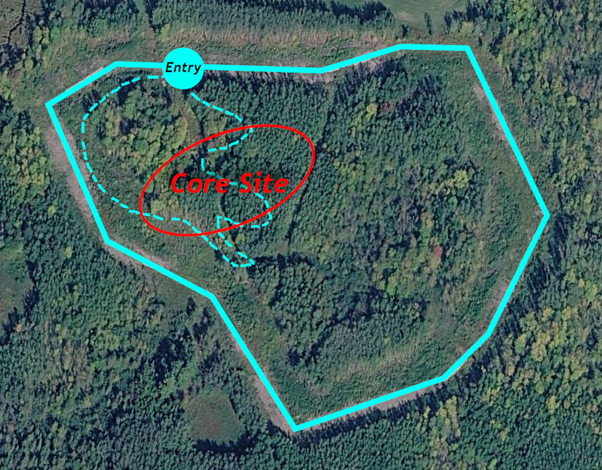

**Combined PCA**

### Methods

Boot swabs from the PPE analysis and stainless-steel swabs from the bird-feeder sentinel analysis were pooled into a single dataset. Pairwise correlations among MPR, MS, and AUC were visualized as hexagonal density scatter plots with ordinary least-squares fits overlaid in both raw and log-transformed space, with R² reported for each. A joint PCA was run on both raw and log-transformed metrics (`prcomp()`, scaled and centered) to compare variance explained by PC1 across transformations and to evaluate whether the two sample types occupy overlapping regions of metric space.

### Results

#### Data Summary

Sample counts by dataset and location.

| Location | Bird Feeder | PPE Swabs |
| --- | --- | --- |
| negative site | 3 | 93 |
| dump site | 24 | 136 |
| perimeter | 24 | 16 |

#### Untransformed metrics

```
Importance of components:
                          PC1     PC2     PC3
Standard deviation     1.6435 0.47495 0.27108
Proportion of Variance 0.9003 0.07519 0.02449
Cumulative Proportion  0.9003 0.97551 1.00000
```

#### Log-transformed metrics

```
Importance of components:
                          PC1     PC2     PC3
Standard deviation     1.6375 0.50541 0.25146
Proportion of Variance 0.8938 0.08515 0.02108
Cumulative Proportion  0.8938 0.97892 1.00000
```

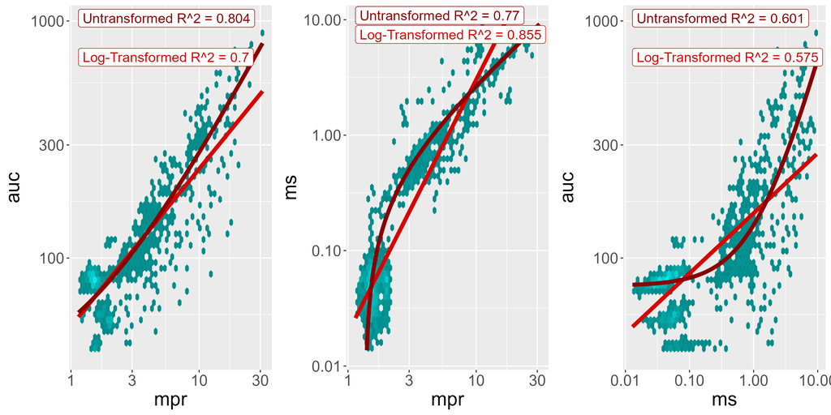

Pairwise metric correlations across the combined PPE and sentinel dataset.

**PPE Swabs**

### Methods

Metrics (MPR, MS, AUC) were median-aggregated per sample across replicate wells before analysis. **Samples were excluded if all four metrics (MPR, MS, AUC, QR) were missing, if they came from the perimeter location, if they were collected post-decontamination, or if the surface was not a boot or blank.** This restricted the dataset to boot and blank swabs from the Core (dump) and Negative sites at pre- and post-sampling timepoints.

### Results

#### Data Summary

Unique sample counts by location and timing.

| Location | post-sampling | pre-sampling |
| --- | --- | --- |
| dump site | 56 | 52 |
| negative site | 33 | 32 |

#### PCA Analysis

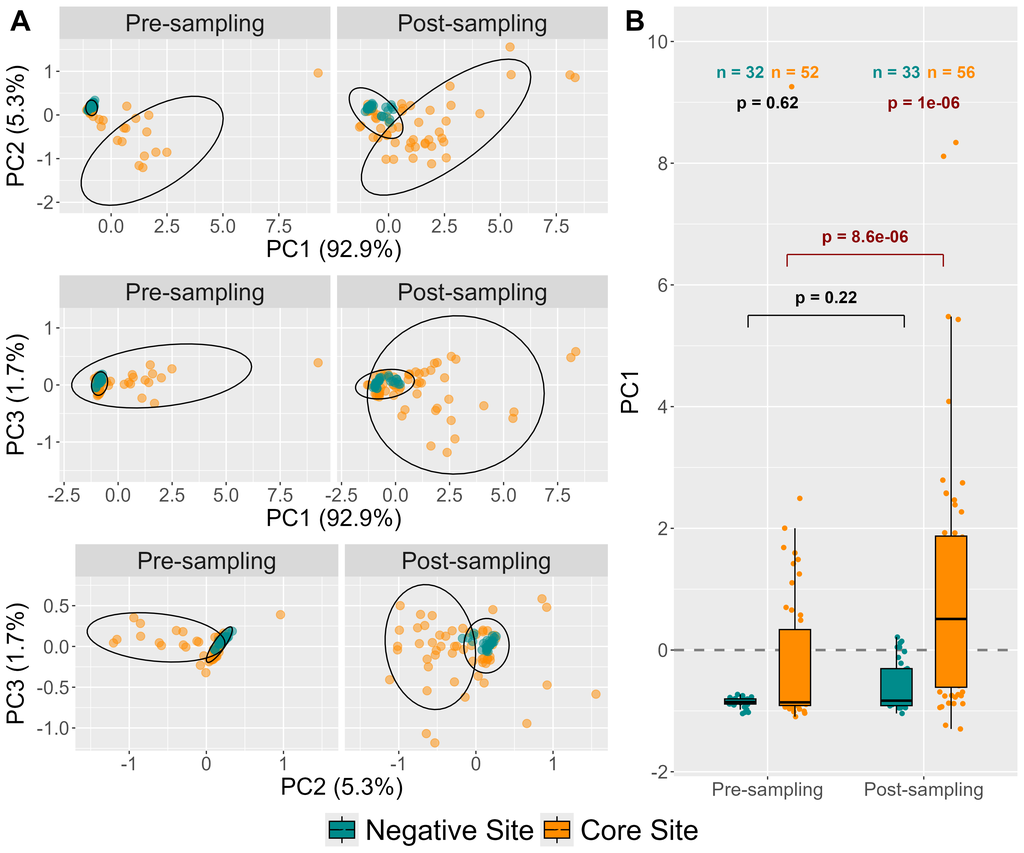

PCA score scatter (PC pairs) colored by location with k-means cluster ellipses. Inset boxplot shows PC1 by timing and location.

#### Surface Location

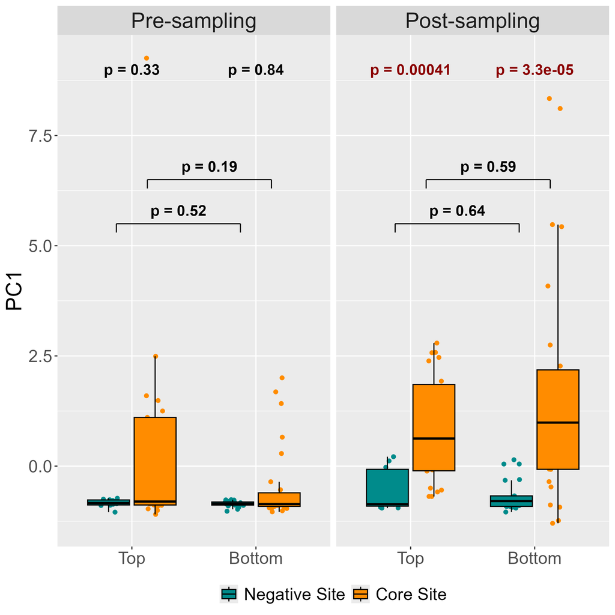

PC1 by boot side (top vs. bottom), faceted by timing.

**Bird Feeder Sentinels**

### Methods

RT-QuIC metrics (MPR, MS, AUC) were median aggregated and swabs were limited to the stainless-steel sentinel swabs (excluding the plastic sentinels).

Metrics were submitted to principal component analysis (`prcomp()`, scaled and centered). PC1 was used as the summary contamination score throughout. Group-level means per site × side × timepoint were compared against the pooled negative-control distribution using one-sided Wilcoxon rank-sum tests (alternative: greater). Temporal trends in PC1 were estimated by linear regression (PC1 ~ days since deployment start) separately for each site, restricted to established sentinels deployed for ≥700 days and excluding re-extracted samples. Cross-year within-site differences were assessed using a two-way ANOVA (PC1 ~ site × year) followed by Tukey HSD post-hoc tests.

### Results

#### Data Summary

Observations by site and sampling year.

| Site | 2023 | 2024 | 2025 |
| --- | --- | --- | --- |
| control | 0 | 24 | 0 |
| dump site | 48 | 32 | 64 |
| perimeter | 48 | 48 | 48 |

#### PCA Analysis

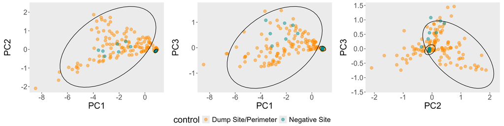

PCA score scatter (PC pairs) colored by site type, with k-means cluster ellipses.

#### Temporal Trends

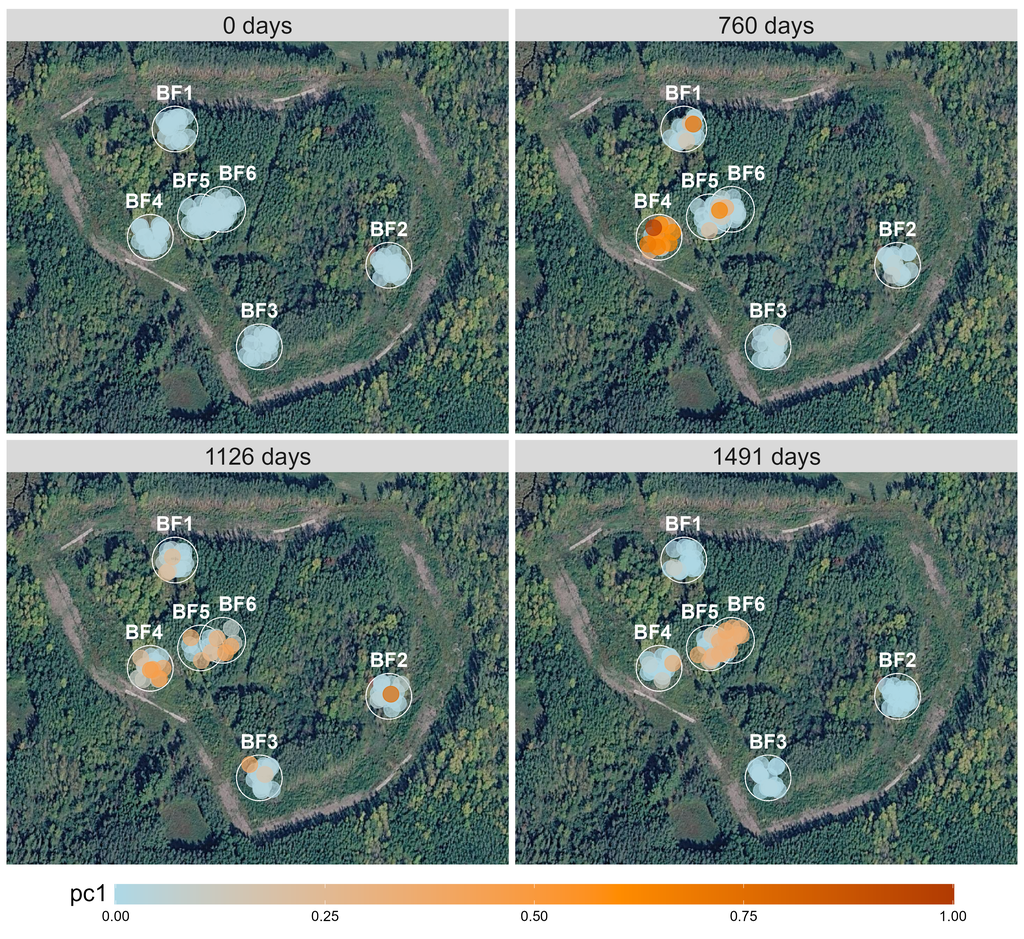

Linear model results: PC1 ~ days since deployment start, by site.

[output not shown]

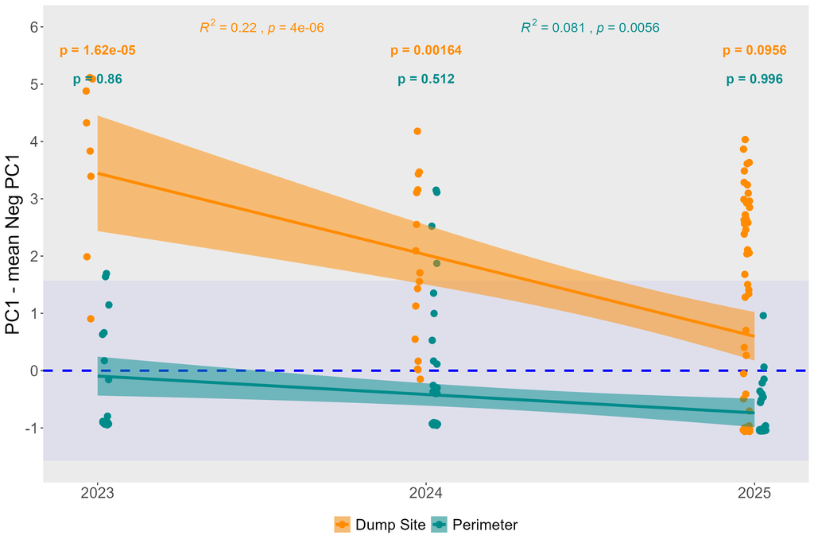

PC1 (relative to negative-site mean) vs. sampling year, by site.

#### Per-Plate Summary

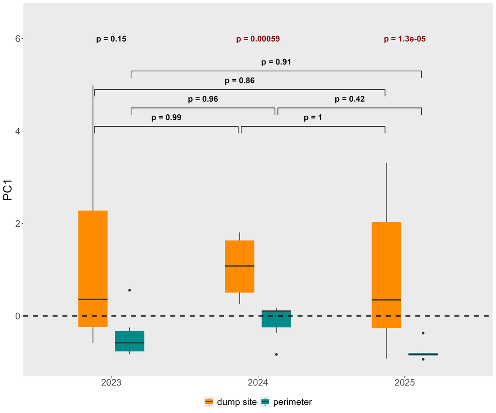